# Hour 3 — Communicate: Fatal Car Crashes on 4/20

From analysis to publication | TheDataShrink™

Author

TheDataShrink™

Published

April 24, 2026

**TheDataShrink™ — Data stories worth sharing.**

Episode: `fatal_car_crashes_on_4_20` | [All episodes](https://thedatashrink.com.au/tidytuesday) | YouTube | Instagram

**What Hour 3 Is For**

Turn the EDA + modeling work into content that a non-data-science audience will understand, share, and remember. Every chart here should be able to stand alone without a caption explaining what the axes mean.

## 1 The Publication Goal

| Channel | Format | Objective |
| --- | --- | --- |
| YouTube | 15–20 min video | Full walkthrough, show live R coding |
| Instagram | 5-slide carousel | Stop the scroll, one insight per slide |
| Facebook | Text + hero chart | 3 bullet findings + link |
| Website | Quarto HTML page | SEO-optimised, embedded interactive |

## 2 Setup

```r
library(tidyverse)
library(lubridate)
library(broom)
library(ggtext)
library(scales)

TDS_BLUE  <- "#1b6ca8"
TDS_GOLD  <- "#c8a415"
TDS_DARK  <- "#1a1a2e"
TDS_RED   <- "#c0392b"
TDS_LIGHT <- "#f8f9fa"

theme_set(theme_light(base_size = 14))
```

## 3 Load Data

```r
base_url <- "https://raw.githubusercontent.com/rfordatascience/tidytuesday/main/data/2025/2025-04-22"

daily_accidents     <- read_csv(file.path(base_url, "daily_accidents.csv"))
daily_accidents_420 <- read_csv(file.path(base_url, "daily_accidents_420.csv"))
```

## 4 The Hero Chart

**Design Brief**

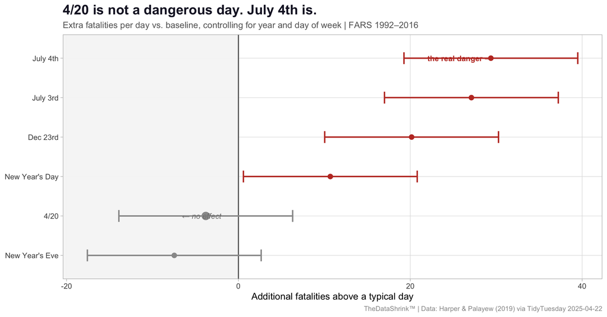

```r
holiday_data <- daily_accidents |>
  mutate(
    year      = year(date),
    wday      = wday(date, label = TRUE),
    month_day = format(date, "%m-%d"),
    holiday   = case_when(
      month_day == "07-04" ~ "July 4th",
      month_day == "07-03" ~ "July 3rd",
      month_day == "01-01" ~ "New Year's Day",
      month_day == "12-31" ~ "New Year's Eve",
      month_day == "12-23" ~ "Dec 23rd",
      month_day == "04-20" ~ "4/20",
      TRUE                 ~ "Baseline"
    ),
    holiday = fct_relevel(holiday, "Baseline")
  )

model_holidays <- lm(
  fatalities_count ~ holiday + year + wday,
  data = holiday_data
)

coef_data <- tidy(model_holidays, conf.int = TRUE) |>
  filter(str_detect(term, "^holiday")) |>
  mutate(
    term   = str_remove(term, "^holiday"),
    term   = fct_reorder(term, estimate),
    is_420 = term == "4/20",
    significant = !(conf.low < 0 & conf.high > 0)
  )

coef_data |>
  ggplot(aes(estimate, term)) +
  geom_rect(
    xmin = -Inf, xmax = 0, ymin = -Inf, ymax = Inf,
    fill = "#f5f5f5", alpha = 0.5
  ) +
  geom_vline(xintercept = 0, colour = "grey40", linewidth = 0.8) +
  geom_errorbarh(
    aes(xmin = conf.low, xmax = conf.high,
        colour = significant),
    height = 0.3, linewidth = 1
  ) +
  geom_point(
    aes(colour = significant, size = is_420)
  ) +
  scale_colour_manual(
    values = c("TRUE" = TDS_RED, "FALSE" = "grey60"),
    guide  = "none"
  ) +
  scale_size_manual(values = c("FALSE" = 3, "TRUE" = 5), guide = "none") +
  annotate(
    "text", x = -2, y = "4/20",
    label = "← no effect",
    colour = "grey50", size = 4, fontface = "italic", hjust = 1
  ) +
  annotate(
    "text", x = 22, y = "July 4th",
    label = "the real danger →",
    colour = TDS_RED, size = 4, fontface = "bold", hjust = 0
  ) +
  labs(
    title    = "4/20 is not a dangerous day. July 4th is.",
    subtitle = "Extra fatalities per day vs. baseline, controlling for year and day of week | FARS 1992–2016",
    x        = "Additional fatalities above a typical day",
    y        = NULL,
    caption  = "TheDataShrink™ | Data: Harper & Palayew (2019) via TidyTuesday 2025-04-22"
  ) +
  theme(
    plot.title    = element_text(face = "bold", size = 20, colour = TDS_DARK),
    plot.subtitle = element_text(size = 13, colour = "grey40"),
    plot.caption  = element_text(size = 10, colour = "grey60"),
    panel.grid.minor = element_blank()
  )
```

```r
ggsave(
  "hero_fatal_car_crashes_on_4_20.png",
  width = 12.5, height = 6.54, dpi = 150
)
```

**Why This Chart Works**

- The title is the finding — you don’t need to read the axes
- Red = significant effect, grey = not significant — one visual encoding, no legend needed
- The annotation “← no effect” points directly at 4/20 so even a fast scroll reader gets it
- July 4th sits clearly to the right — the contrast is immediate

## 5 Instagram Carousel Copy

**Slide 1 — Hook** *(full bleed, bold text on dark background)* > “A 2018 study said 4/20 causes more fatal car crashes. > A 2019 study proved them wrong. > Here’s what the data actually shows. 🧵”

**Slide 2 — Data** *(show the calendar chart from H1)* > “25 years of US fatal crash data. > 1992 to 2016. Every single day. > One date was supposed to stand out.”

**Slide 4 — Method** *(code snippet or coefficient plot)* > “The original paper compared 4/20 to a narrow window of nearby days. > No trend adjustment. No day-of-week control. > Change those two things — the effect disappears.”

**Slide 5 — CTA** > “Full analysis with code on YouTube 👆 > Built in R with tidyverse + broom + rsample. > Follow @thedatashrink for weekly data stories. 📊”

## 6 YouTube Chapter Timestamps

```
0:00  Intro — A paper, a rebuttal, and a lesson about analysis
2:00  The data — FARS 1992–2016, three tables explained
5:00  Act 1 — The baseline: which days are actually dangerous?
9:00  Act 2 — Replicating the misleading Staples & Redelmeier finding
13:00 Act 3 — The Harper & Palayew correction
17:00 Act 4 — The model: holiday effect sizes with confidence intervals
22:00 Act 5 — Bootstrap CIs: closing the argument
26:00 The hero chart — one image that tells the whole story
28:00 Key takeaway: it was never about cannabis
```

## 7 Facebook Post Template

[output not shown]

## 8 SEO Metadata

```yaml
# Add to Quarto YAML for the published page:
description: >
  Did 4/20 really cause more fatal car crashes? We replicate both the
  original 2018 finding and the 2019 rebuttal in R — and show exactly
  where the analysis went wrong.
keywords:
  - R
  - TidyTuesday
  - traffic fatalities
  - 4/20
  - FARS data
  - data literacy
  - broom
  - rsample
image: "hero_fatal_car_crashes_on_4_20.png"
open-graph:
  title: "4/20 is not a dangerous day. July 4th is."
  image: "hero_fatal_car_crashes_on_4_20.png"
twitter-card:
  title: "4/20 is not a dangerous day. July 4th is."
  image: "hero_fatal_car_crashes_on_4_20.png"
  card-style: summary_large_image
```

## 9 Interactive Element (Shiny)

```r
library(shiny)

# Minimal Shiny: pick any calendar date, see how it compares to the annual baseline
ui <- fluidPage(
  titlePanel("How dangerous is your birthday?"),
  sidebarLayout(
    sidebarPanel(
      dateInput("date", "Pick a date (month + day used):",
                value = "2000-04-20",
                format = "mm-dd")
    ),
    mainPanel(plotOutput("comparison"))
  )
)

server <- function(input, output) {
  output$comparison <- renderPlot({
    target_md <- format(as.Date(input$date), "%m-%d")

    daily_accidents |>
      mutate(
        month_day = format(date, "%m-%d"),
        group     = if_else(month_day == target_md,
                            paste0("Your date (", target_md, ")"),
                            "All other days")
      ) |>
      ggplot(aes(group, fatalities_count, fill = group)) +
      geom_boxplot(show.legend = FALSE) +
      scale_fill_manual(values = c("All other days" = TDS_BLUE,
                                   paste0("Your date (", target_md, ")") = TDS_GOLD)) +
      labs(title = paste("Fatalities on", target_md, "vs. every other day"),
           x = NULL, y = "Daily fatalities") +
      theme_light(base_size = 14)
  })
}

shinyApp(ui, server)
```

## 11 Cross-Reference

- ← Hour 1 EDA
- ← Hour 2 Modeling